# Lab 11: Some more Missing Data and intro to HLM

Mateo Villamizar Chaparro

10/29/2020

## **Important Information**:

1. **Office hours** are back!
2. **Labs**: Fridays from 10:15-11:30 (https://duke.zoom.us/j/93156474311)
3. Short paper 2 is due Nov. 13.

## **Some comments regarding PS4**

- Whenever you deal with interactions, remember to include them within the loop (if they change).
- You can calculate interactions just using $y\sim x*z$. This would show each individual varaible and the interaction. There is no need to create a new variable in most cases.
- Be careful when calculating first differences

## **Some more Missing Data**

For todays lab, we are going to see how to use MICE to deal with missing data. Let’s use the data from [Kubota and Milner (2005)](https://scholar.princeton.edu/hvmilner/publications/why-move-free-trade-democracy-and-trade-policy-developing-countries). I eliminated some of the variables so we can have a similar dataset as the one in the course slides. The final varaibles are:

- **country:** Country number id
- **ctylabel:** Country name
- **year:** Year
- **gdp:** GDP per capita
- **newtar:** New tariff
- **polity:** Measure of democracy
- **signed:** Signed an agreement with the MFI
- **usheg:** sum of US exports and imports as a percent of world trade+

### *Evaluating Missingness*

```r
dat <- read.dta("KM_2005.dta")

# Change the scale of some of the variables
dat$gdp <- dat$gdp/1E4
dat$usheg <- dat$usheg*10

# Look at the percentage of missing data by variable
apply(dat, 2, function(x) round(mean(is.na(x)==TRUE)*100,1))
```

```
##  country ctylabel     year      gdp   newtar   polity   signed    usheg
##      0.0      0.0      0.0     31.3     83.1     37.3     25.4      0.0
```

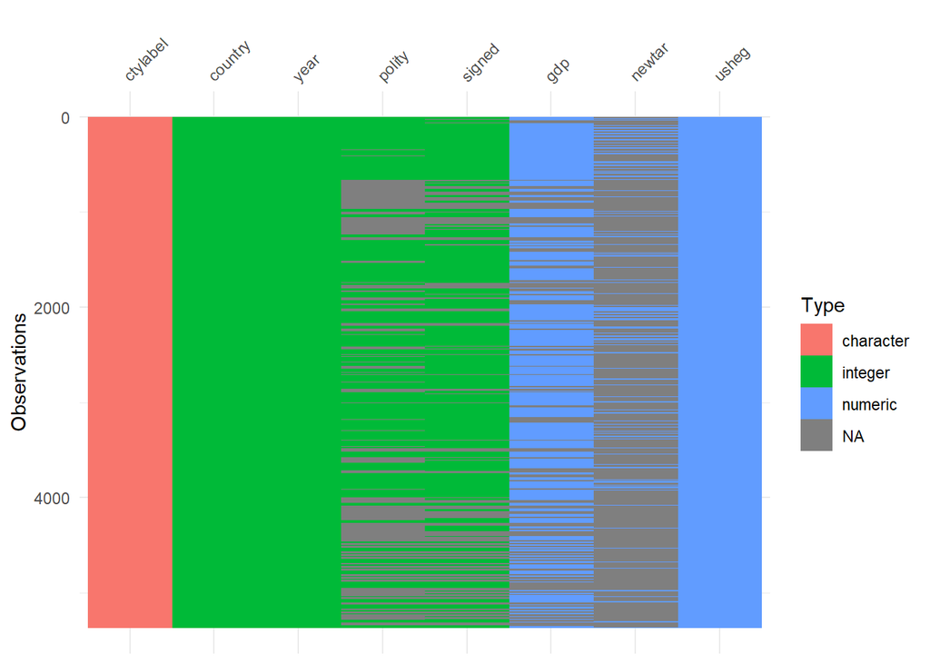

```r
# Notice that our sample is larger than the sample seen in class, that is why numbers differ

# Let's see this visually
visdat::vis_dat(dat)
```

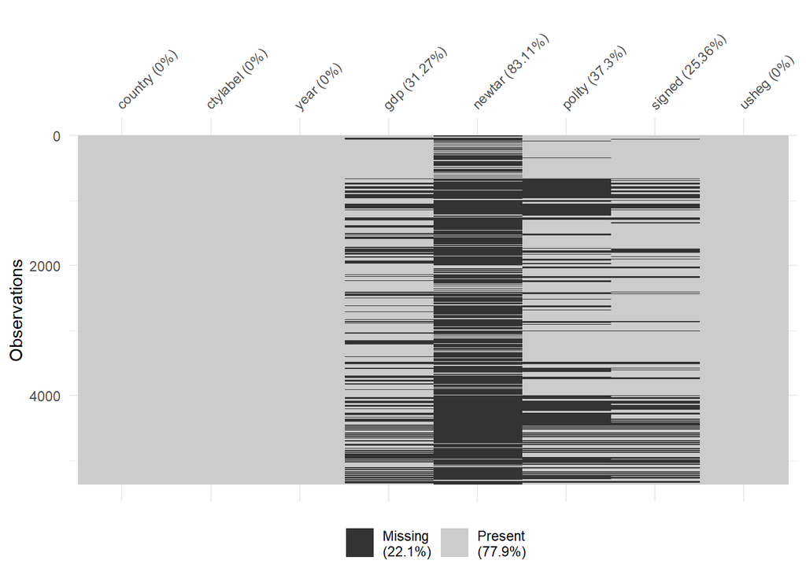

```r
visdat::vis_miss(dat)
```

There is quite some missingness in the data, let’s try to solve it using different methods again.

1. Listwise deletion

```r
# create the dataset with omitted missing values
dat_lw <- na.omit(dat) # Note that we can skip this step as the lm command omits NA values

# Create a container for the regression formula
f <- newtar ~ polity + gdp + signed + usheg + country

# Calculate the model
m_lw <- lm(f, data = dat_lw)
```

2. Mean imputation

```r
# Create the new dataset with the mean imputed values
df_mean <- dat
df_mean$newtar[is.na(df_mean$newtar)] <- mean(df_mean$newtar, na.rm = TRUE)
df_mean$polity[is.na(df_mean$polity)] <- mean(df_mean$polity, na.rm = TRUE)
df_mean$signed[is.na(df_mean$signed)] <- mean(df_mean$signed, na.rm = TRUE)
df_mean$gdp[is.na(df_mean$gdp)] <- mean(df_mean$gdp, na.rm = TRUE)

# Calculate the model
m_mi <- lm(f, data = df_mean)
```

3. Random Imputation. We will do just one imputed dataset since we did multiple last lab.

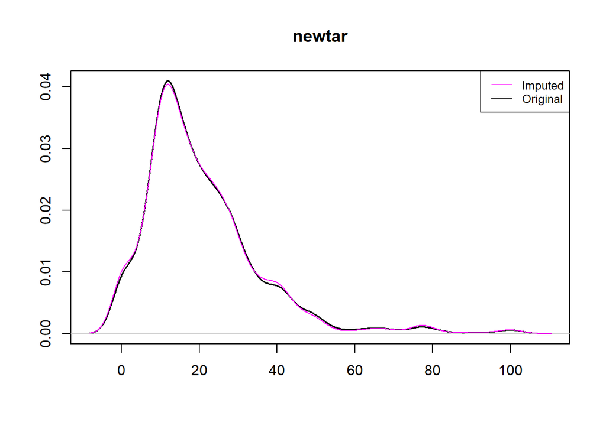

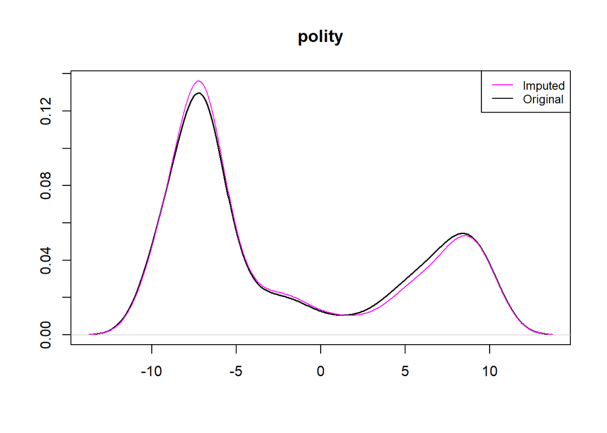

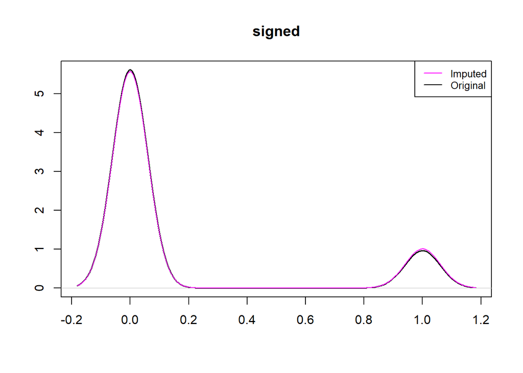

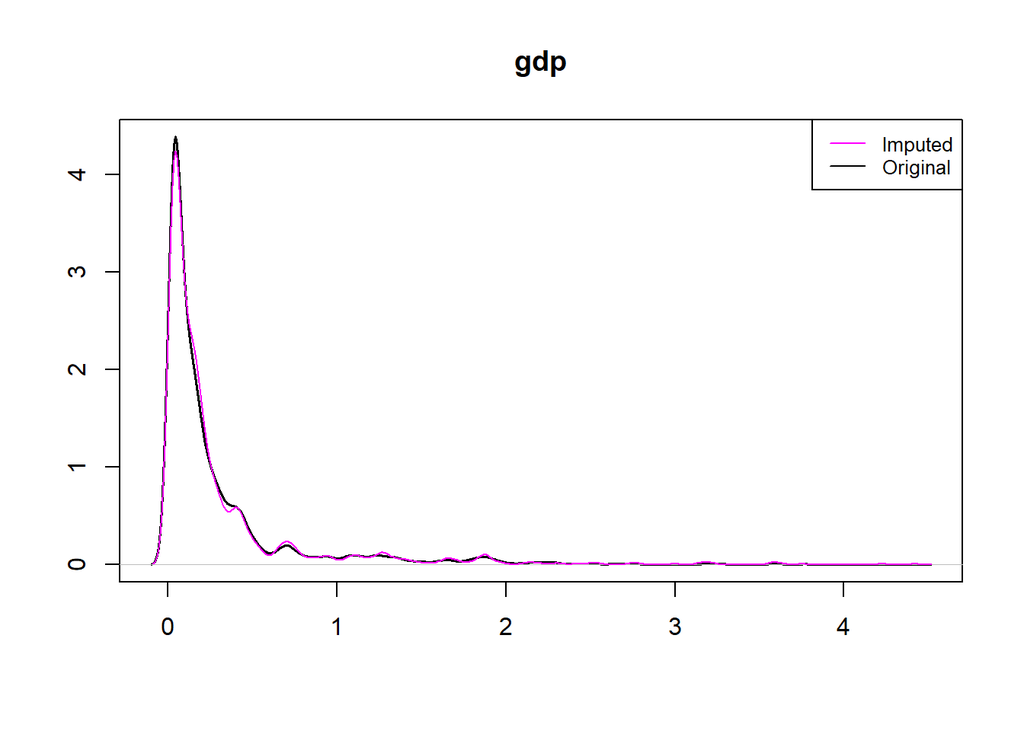

```r
# Recall the random imputation function

r_imp <- function(x){
  mis <- is.na(x)
  obs <- x[!mis]
  x[mis] <- sample(x=obs, size=sum(mis), replace=T)
  return(x)
}

# Create the dataset with random imputation
sel <- c("newtar", "polity", "signed", "gdp")
dat_i_rnd <- dat
dat_i_rnd[, sel] <- apply(dat_i_rnd[, sel], 2, r_imp)

# Let's see the distributions visually
for (i in sel) {
  dens <- density(dat[, i], na.rm=T)
  bw <- dens$bw
  dens_i <- density(dat_i_rnd[is.na(dat[, i]), i], bw=bw)
  lims <- c(min(dens$y, dens_i$y), max(dens$y, dens_i$y))
  plot(dens, lwd = 1.8, main = i, ylim = lims, xlab = "", ylab = "")
  lines(dens_i, lwd = 1.4, col = "magenta")
  legend("topright", horiz = F, legend = c("Imputed", "Original"), col = c("magenta", "black"),lty = c(1,1), cex = .8)
}
```

```r
# Let's calculate the model
m_ri <- lm(f, data = dat_i_rnd)

stargazer::stargazer(m_lw, m_mi, m_ri, type = "text")
```

```
##
## ============================================================================================
##                                               Dependent variable:
##                     ------------------------------------------------------------------------
##                                                      newtar
##                               (1)                     (2)                      (3)
## --------------------------------------------------------------------------------------------
## polity                     -0.191**                 -0.039**                 -0.023
##                             (0.077)                 (0.015)                  (0.030)
##
## gdp                       -14.314***               -2.903***                -1.733***
##                             (1.433)                 (0.217)                  (0.434)
##
## signed                       0.684                  0.590**                  -1.104*
##                             (1.262)                 (0.273)                  (0.580)
##
## usheg                      -9.781***                -1.189**                 -0.753
##                             (3.469)                 (0.526)                  (1.300)
##
## country                     -0.001                  0.00001                  -0.001
##                             (0.003)                 (0.0004)                 (0.001)
##
## Constant                   53.406***               24.408***                23.664***
##                             (9.708)                 (1.445)                  (3.566)
##
## --------------------------------------------------------------------------------------------
## Observations                  766                    5,370                    5,370
## R2                           0.141                   0.037                    0.004
## Adjusted R2                  0.136                   0.036                    0.003
## Residual Std. Error    14.025 (df = 760)       6.075 (df = 5364)       15.053 (df = 5364)
## F Statistic         25.016*** (df = 5; 760) 41.048*** (df = 5; 5364) 3.991*** (df = 5; 5364)
## ============================================================================================
## Note:                                                            *p<0.1; **p<0.05; ***p<0.01
```

4. Using MICE and the *mice* package. The idea behind MICE is related to some tools from Bayesian Statistics. But put it bluntly, it tries to impute data using an algorithm that uses full conditionals to calculate the missing observations under a series of iterations. Each incomplete variable is calculated using a different model. Most of these algorithms tend to use a ultivariate normal distribution to calculate the parameters, and as such, it is sometimes a good idea to transform some of the variables’ distributions into normal distributions (ie logs, $\sqrt{counts}$, etc). The model documentation can be found [here](https://cran.r-project.org/web/packages/mice/mice.pdf). In very simplistic terms:
1. Draw $D_{mis}$ from a probability model $P(D_{mis}|D_{obs},\tilde\theta)$. This could be a linear regression model, where $\theta$ are the parameters of the model. You would also need a good starting point, usually MLEs are the most common.
2. Replace the calculated $D_{mis}$ into a conditional $P(\theta|D_{obs},\tilde D_{mis})$
3. Replace the calculated $\theta$ into $P(D_{mis}|D_{obs},\tilde\theta)$ to obtain a new draw for $D_{mis}$. Do this iteration until convergence. Here convergence is done **stochastically** not **deterministically**. This means, we converge to a distribution and not a point. We will see this in some of the plots.

```r
library(mice)

# Calculate the new datasets
dat_i_ce <- mice(data=dat,                 # name of the dataset with missing values
                 m = 10,                   # Number of imputations, default is 5
                 maxit = 15,               # Maximum number of iterations, default is 5
                 method = "norm.nob")      # Imputation method used for the variables (can be a vector of strings if multiple methods are needed)
```

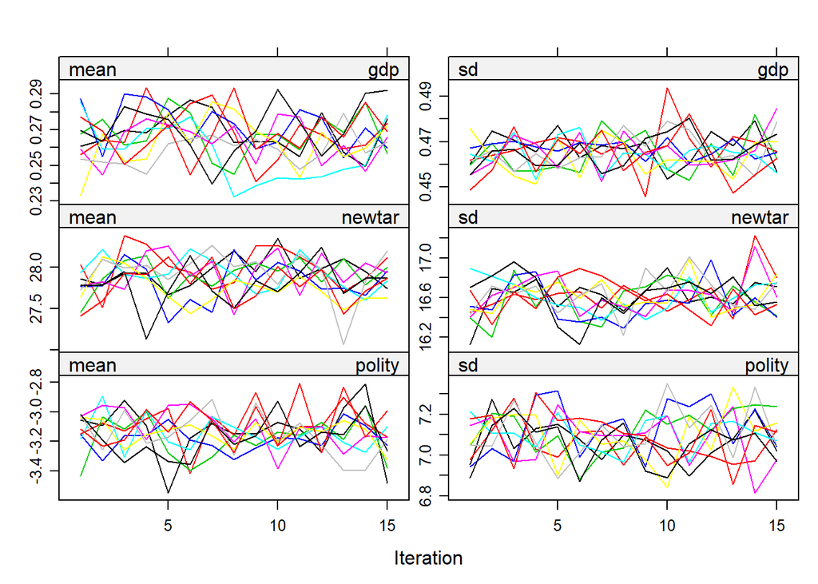

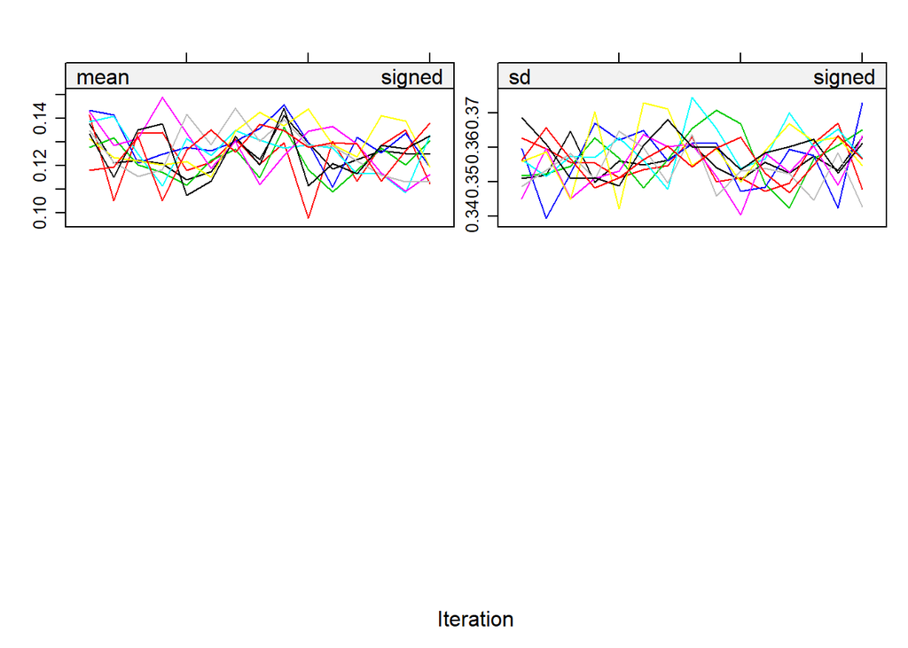

```r
# Let's plot some of the results by each iteration of the algorithm to see convergence (these are called traceplots)
plot(dat_i_ce)
```